# Coral Reef Gender & Diversity Analysis

Sam Cheng

01/18/2020

## Introduction

The goal of this project is to examine patterns in author diversity (gender/geographic) in coral reef publications over the past 15 years. We selected a range of peer-reviewed scientific journals across different impact factors and levels (incl. Conservation Letters, PNAS, Proceedings of the Royal Society B, Coral Reefs, PlosOne, Marine Policy, Marine Biology, Frontiers in Marine Science, Nature, Science). A team of global coral reef scientists reviewed these articles and extracted relevant data on research area, geography, authorship, and gender.

**Notes for co-authors to consider are in bold purple**

## Summary statistics

**The number of unique authors is going to be wrong as names were not standardized between databases). We need to decide whether we want to spend time cleaning this or not. Variations include Last,First; First Last; Last, First Initial**

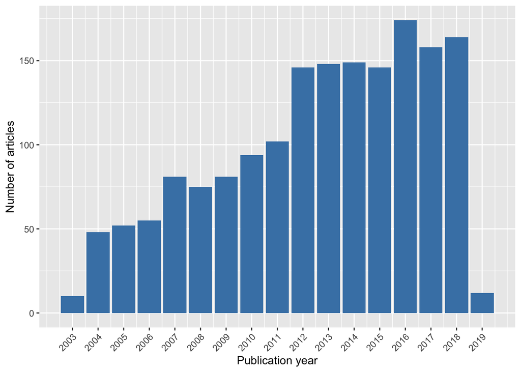

**Figure 1.** Growth in coral reef publications over the last 15 years

Research was conducted in `95` countries and `18` territories. The most studied countries were Australia `Australia` (n=`459`) and `United States` (n=`238`).

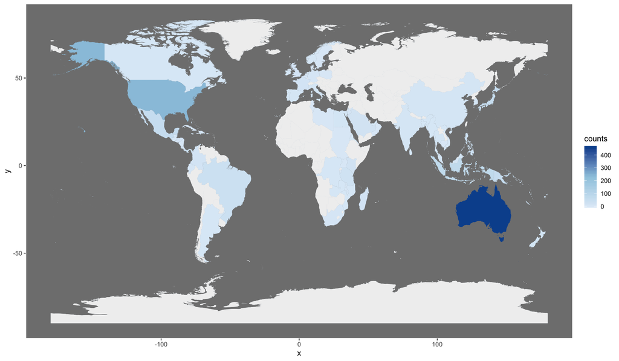

**Figure 2.** Geographic distribution of study countries

**This one needs the legend to look nicer

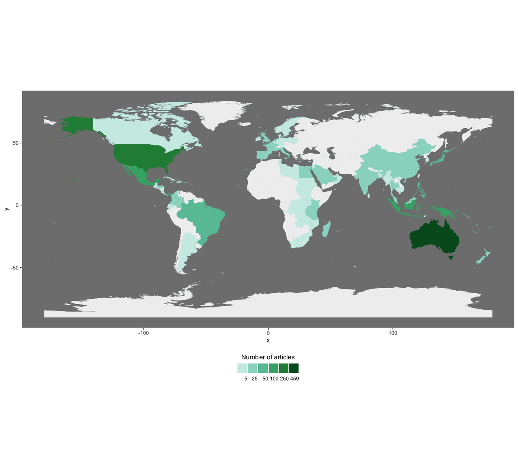

**Figure 2 (alternate).** Geographic distribution of study countries with discrete breaks

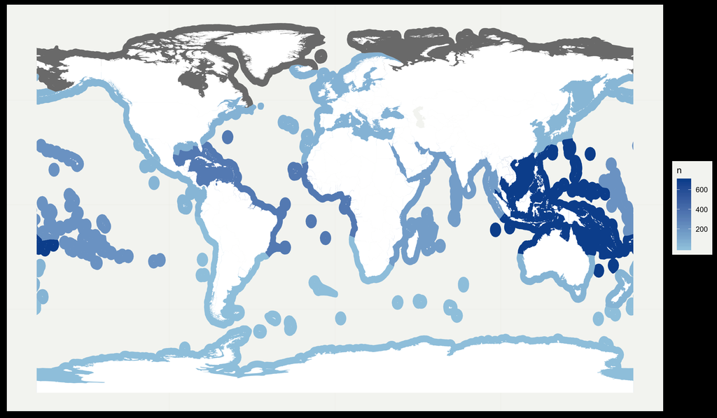

**Figure 3. Distribution of research effort over marine realms**

Total articles by marine realm

| id | n |
| --- | --- |
| Central Indo-Pacific | 694 |
| Tropical Atlantic | 333 |
| Eastern Indo-Pacific | 203 |
| Western Indo-Pacific | 151 |
| Temperate Northern Atlantic | 51 |
| Temperate Australasia | 46 |
| Tropical Eastern Pacific | 43 |
| Temperate Northern Pacific | 37 |
| Temperate Southern Africa | 4 |
| Southern Ocean | 1 |
| Temperate South America | 1 |

## Research topics and study types

Research topics were wide-ranging.

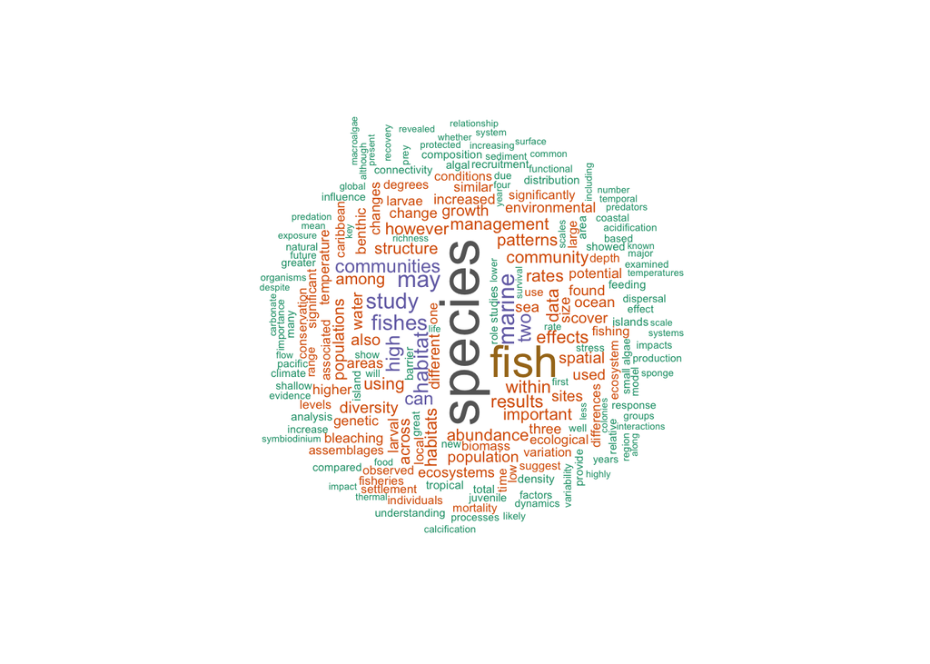

**Figure X.** Wordcloud of frequent words appearing in titles and abstracts

## Author characteristics (gender, diversity)

This study found a maximum of `5290` unique authors in the evidence base. This number represents the maximum number of authors as different publication databases listed authors in different formats and thus we were unable to de-duplicate entries that were not an exact match (e.g. Last Name, First Name vs. Last Name, First Initial). `59` authors could not be located on the internet to confirm gender identity. Authors whose gender identity could not be reliably determined based on the presence of identified pronouns, declarations, or author(s) knowledge - were coded as “undetermined.” The majority of authors in coral reef science are male.

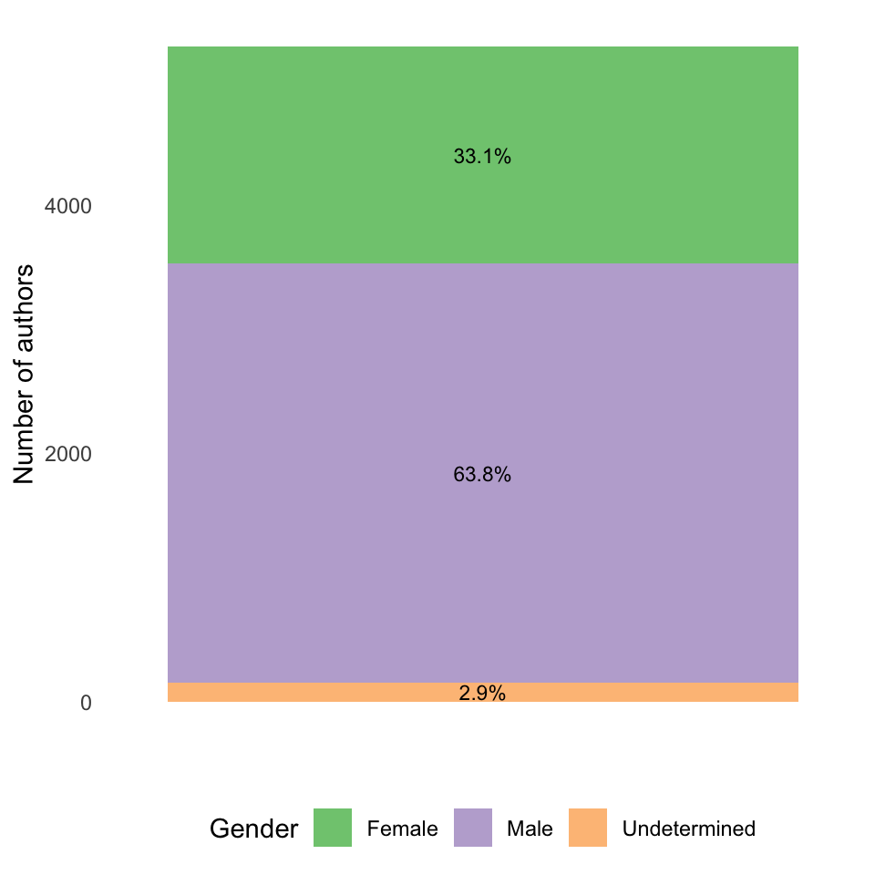

**Figure X.** Gender distribution of authors in coral reef science

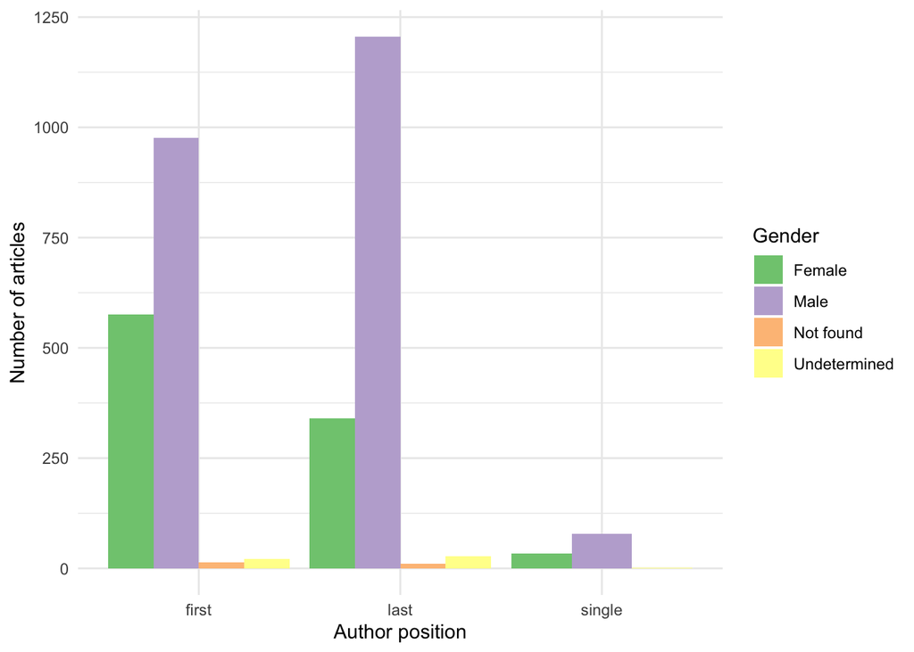

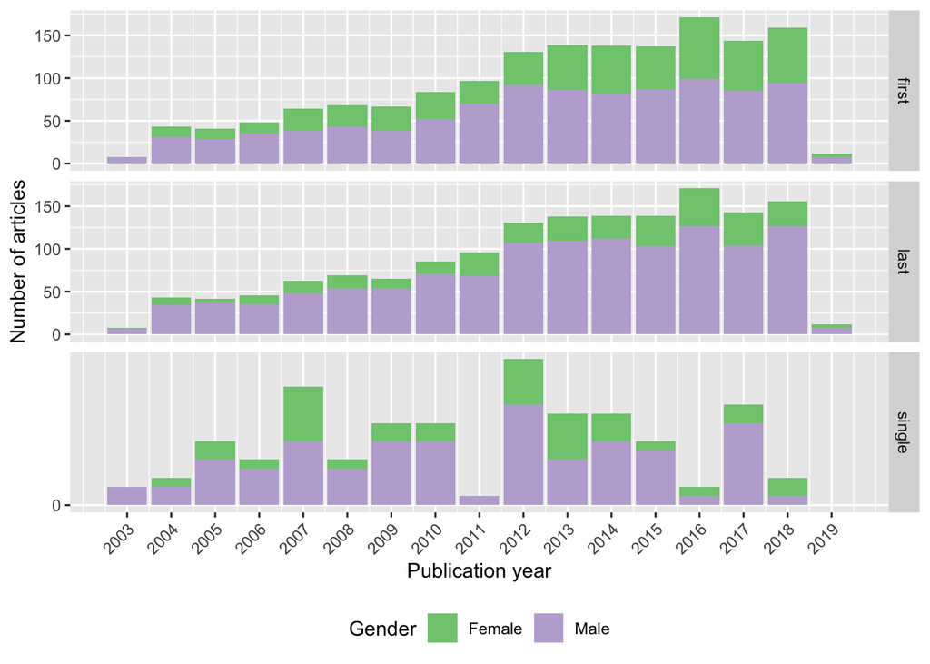

**Figure X.** Change in proportion of genders in first, last, and single author positions over time

Authors hailed from numerous different countries